# Manuscript_draft

Lorenzo Menichetti

2023-04-24

# Title

# Abstract

# Introduction

## Agroforestry and SOC

## Introducing the problem: it is difficult to relate the SOC stocks with AFS treatments

### Variability

### Limited data availability over time and space

## What we did to solve it

### We collected more data

### We integrated the data with more sources (SoilGrids)

### We analyzed the data with a nonparametric ML technique

### We decomposed the variance of the models

# Materials and Methods

## Data mining

This study was initially conducted with a literature review aiming studies related to AFS and SOC Stocks, including SOC Content and bulk density. Among the research engines, for this study it was used: ISI—Web of Knowledge, Google Scholar, Scopus, Research Gate, and Scielo.org. In order to increase the number of potential references, it was used the following keywords: soil AND (‘carbon stock*’ OR ‘carbon pool*’ OR ‘carbon sequestration’ OR ‘carbon concentration’) AND (agroforest* OR parkland* OR homegarden OR multistrata OR hedgerow OR windbreak OR shelter-belt OR ‘live fence’ OR ‘tree intercrop*’ OR silvo*arable OR silvo*pasture OR ‘rotation*wood*’ OR tree*fallow* OR fallow OR (tree* AND ‘improve* fallow*’) OR (tree* AND relay*crop*) OR (tree* AND alley*crop*)) (Cardinael et al., 2019). Them it was filled a table with several parameters found in the papers, including Location, Climate Classification according to Köppen, Physical Property of the Soil, AFS Description, Previous Land Use, Age of System, SOC Stock from the AFS and from the Control plot, following the IPCC guidelines (IPCC, 2022). Over 400 peer reviewed papers have been examined and 174 have been considered adequate for this study. The eligibility of the papers was the presence of SOC Stocks data, measured in the AFS and a control area (synchronic); or SOC data sampled before and after the AFS implementation (diachronic).

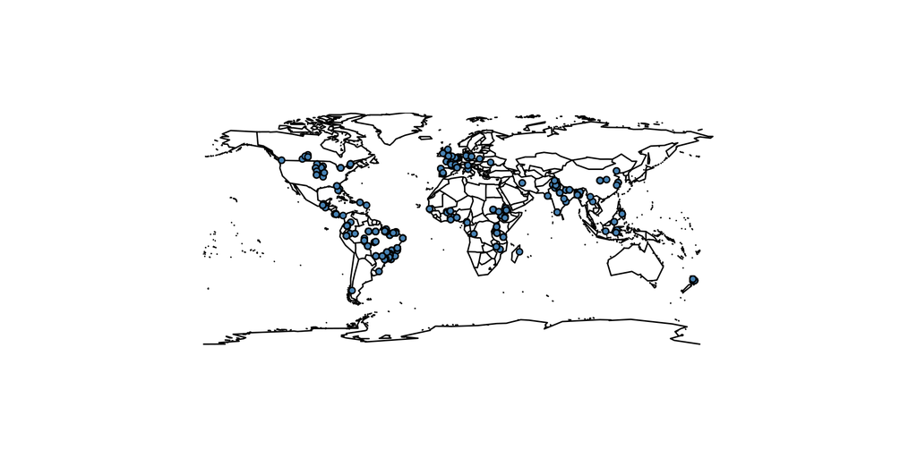

The dataset

## Data treatment

### Outliers detection

### Integration with variables from the SoilGrids database

## Random forest model development

### Introducing the method briefly

### The different models we tested

| Model.description | Model.name |
| --- | --- |
| Stocks difference, without SoilGrids data | Model 1 |
| Stocks difference, with SoilGrids data | Model 1.1 |
| Stocks after AFS, without SoilGrids data | Model 2 |
| Stocks after AFS, with SoilGrids data | Model 2.1 |
| Stocks after AFS, with only clay from SoilGrids data | Model 3.1 |
| Stocks after AFS, no previous land use but with SoilGrids data | Model 0 |
| Stocks after AFS, no previous land use | Model 0.1 |

#### The variables we considered

The variables

[output not shown]

#### Predicting the stocks difference

We tested how the differences in C stocks (after AFS treatment and before, assuming that the control treatment from each study was representative of the previous state of the system) can be predicted by a trained model.
Models were all in the form
$$\Delta_{stocks}
\sim f(variable_1, variable_2, variable_{...})$$

#### Predicting the AFS stocks accumulation

Models were all in the form
$$AFS_{stocks}
\sim f(variable_1, variable_2, variable_{...})$$

#### Predicting the AFS stocks accumulation but without including information about previous land use

### Validation approach: fully independent, stratified by cluster

# Results

## The performances of the models on the validation dataset

- The models did not manage to predict reasonably the $\Delta$ in stocks, but they did manage to predict the C stocks after a certain time of agroforestry treatment
- The models perform relatively well (better than random, there is some information) even on a fully independent dataset
- There was virtually no information added from the SoilGrids dataset
- Removing the previous land use information still retains a model with some value (although of course worse than with such information)

A knitr kable.

| Model.type | R.2 |
| --- | --- |
| Stocks difference, without SoilGrids data | 0.2663974 |
| Stocks difference, with SoilGrids data | 0.2207099 |
| Stocks after AFS, without SoilGrids data | 0.3996744 |
| Stocks after AFS, with SoilGrids data | 0.4041894 |
| Stocks after AFS, with only clay from SoilGrids data | 0.3512694 |
| Stocks after AFS, no previous land use but with SoilGrids data | 0.3570584 |
| Stocks after AFS, no previous land use | 0.3086806 |

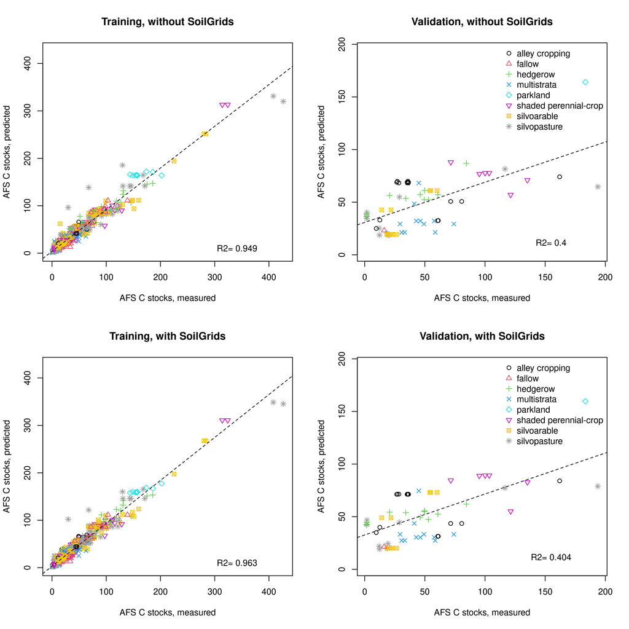

Model evaluation (best models)

## Decomposing the explained variance: the relative variable importance

### Predicting the stocks difference

Stocks difference, without SoilGrids data

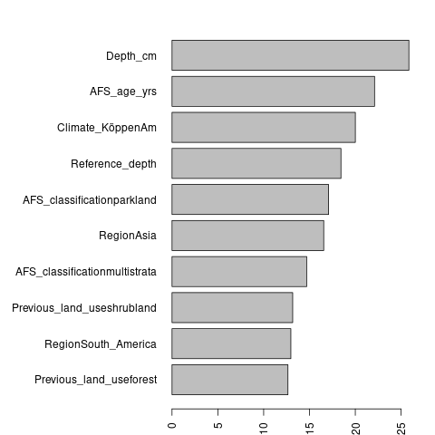

Stocks difference, with SoilGrids data

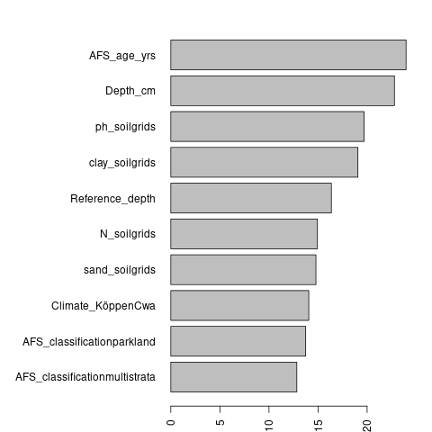

### Predicting the AFS stocks (including information about previous land use) Stocks after AFS, without SoilGrids data

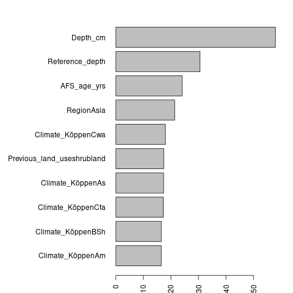

Stocks after AFS, with SoilGrids data

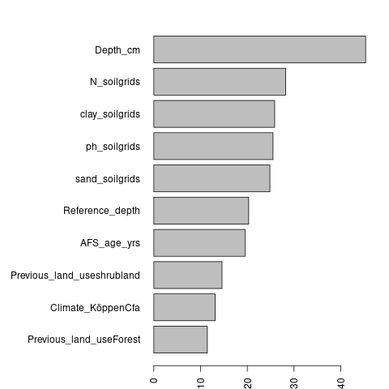

Stocks after AFS, with only clay from SoilGrids data

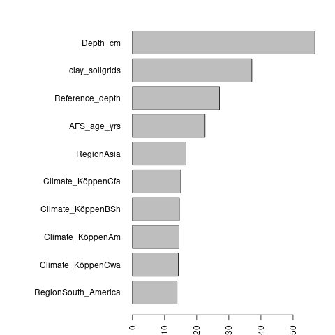

### Predicting the AFS stocks (but without information about previous land use)

[figure not shown]

Stocks after AFS, no previous land use

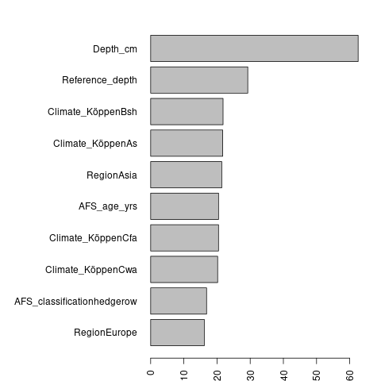

# Discussion

## The $\Delta$ in stocks

## The information from the SoilGrids dataset

## The models as a predictive tool

### Considering previous land use

### Ignoring previous land use

# Conclusions